# Introduction to R

Courses, BA Statistics and Data Science

Oliver Dürr

## Further Resources

- Lot’s of blogposts
  - www.r-bloggers.com
- R for Data Science (free online book)
  - http://r4ds.had.co.nz/
- R is a bit weird compared to other programming languages
  - https://www.johndcook.com/blog/r_language_for_programmers/

## R without computer

**It’s highly recomended to install R and RStudio on your Laptop**

If there is no computer at hand:

- Colab https://colab.research.google.com/notebook#create=true&language=r
- Kaggle Notebooks

## R / Studio

- Rooted in S
  - S started 1976 in Bell Labs by John Chambers
- S Philosophy (user ==>programmer)
  - Interactive environment without needing to do programming
  - Possible to get into programming
- R started in 1991 in as a free version of S
  - Lots of functionality via packages
  - IMO much more stable compared python with pip/conda
- RStudio is the IDE for R
  - Runs on the desktop
  - Runs remote (R-Studio Server)
  - Free but commercial support available

## First Demo

- How to start RStudio
- The 4 Tabs
- 3+4
- Explain

Code at https://github.com/oduerr/stat/tree/master/intro_to_r

# Further Data Structures

## Matrices, List

See Script part1_02_matrices_lists.R

Code at https://github.com/oduerr/stat/tree/master/intro_to_r

# The data structure the data.frame

## The Iris Data Set

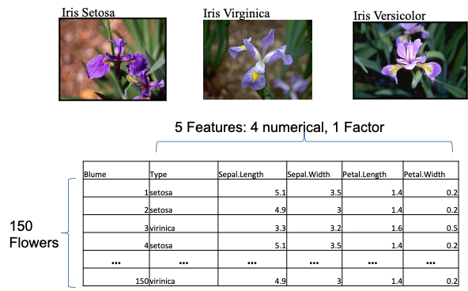

Fisher,R.A. “The use of multiple measurements in taxonomic problems” Annual Eugenics, 7, Part II, 179-188 (1936)

## Demo Data Frame

- Live demo part1_data_frame.R

Code at https://github.com/oduerr/stat/tree/master/intro_to_r

## R and “real” programmers

- “I have written software professionally in perhaps a dozen programming languages, and the hardest language for me to learn has been R. The language is actually fairly simple, but it is unconventional.”<sup>1</sup>
- R is more an interactive environment for data analysis then a programming language
- Strange things

  ```r
  a <- 10
  10 -> a
  this.is.a.variable #no class! _ was not allowed in past
  c(1,2,3)[1] #gives 1, it’s one based
  ```

  - R hates warnings and even more error
  - If something works, does not mean that it worked the way you envisioned
[^1]: https://www.johndcook.com/blog/r_language_for_programmers/

## Loops

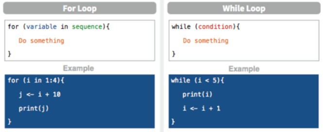

## Conditionals and Functions

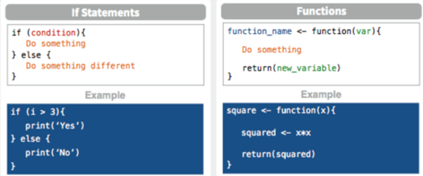

- Functions can have:
  - named arguments
  - default values

## Demo Functions and Loops

- Live demo part1_functions.R

Code at https://github.com/oduerr/stat/tree/master/intro_to_r

https://github.com/oduerr/stat